# Trabajo Final - Estadistica Espacial

Cargamos los paquetes necesarios

```r
library(dplyr)
library(sf)
library(gstat)
library(geoR)
library(spdep)
library(DataExplorer)
library(psych)
library(ggcorrplot)
library(biogeo)
library(ggplot2)
library(leaflet)
```

Cargamos los datasets

```r
estaciones <- read.csv("data_smn/preprocessed/estaciones_smn_v2.csv")
horarios <- read.csv("data_smn/preprocessed/datohorario20210420.csv")
```

Observamos como esta compuesto el dataset

```r
glimpse(estaciones)
```

```
Rows: 123
Columns: 9
$ NOMBRE           <chr> "BASE BELGRANO II", "BASE CARLINI (EX JUBANY)", "BASE ESPERANZA", "BASE MARAMBIO", "BA…
$ PROVINCIA        <chr> "ANTARTIDA", "ANTARTIDA", "ANTARTIDA", "ANTARTIDA", "ANTARTIDA", "ANTARTIDA", "BUENOS …
$ LATITUD_GRADOS   <int> 77, 62, 63, 64, 60, 68, 36, 38, 37, 36, 34, 38, 37, 36, 34, 34, 34, 34, 36, 37, 34, 34…
$ LATITUD_MINUTOS  <int> 52, 14, 24, 14, 45, 8, 50, 44, 43, 12, 32, 1, 26, 21, 36, 49, 33, 58, 2, 56, 33, 41, 4…
$ LONGITUD_GRADOS  <int> 34, 58, 56, 56, 44, 67, 59, 62, 59, 61, 58, 61, 61, 57, 58, 58, 60, 57, 59, 57, 58, 58…
$ LONGITUD_MINUTOS <int> 34, 38, 59, 43, 43, 8, 53, 10, 47, 4, 40, 20, 53, 44, 36, 32, 55, 54, 8, 35, 49, 44, 3…
$ ALTURA           <int> 256, 11, 24, 198, 12, 7, 147, 83, 207, 94, 26, 247, 233, 9, 12, 20, 81, 23, 36, 21, 32…
$ NRO              <int> 89034, 89053, 88963, 89055, 88968, 89066, 87641, 87750, 87649, 87640, 87570, 87683, 87…
$ NroOACI          <chr> "SAYB", "SAYJ", "SAYE", "SAWB", "SAYO", "SAYS", "SAZA", "SAZB", "SAZJ", "SAZI", "SADO"…
```

```r
print("#--------------------#")
```

```
[1] "#--------------------#"
```

```r
glimpse(horarios)
```

```
Rows: 2,041
Columns: 8
$ FECHA  <int> 20042021, 20042021, 20042021, 20042021, 20042021, 20042021, 20042021, 20042021, 20042021, 200420…
$ HORA   <int> 0, 1, 2, 3, 4, 5, 6, 7, 8, 9, 10, 11, 12, 13, 14, 15, 16, 17, 18, 19, 20, 21, 22, 23, 0, 1, 2, 3…
$ TEMP   <dbl> 20.7, 19.8, 19.5, 19.2, 19.2, 18.9, 19.0, 18.8, 19.0, 19.1, 19.9, 20.3, 21.8, 22.9, 23.2, 23.7, …
$ HUM    <int> 70, 79, 79, 81, 81, 84, 84, 84, 84, 84, 81, 82, 68, 72, 68, 66, 71, 68, 75, 72, 73, 68, 68, 68, …
$ PNM    <dbl> 1020.8, 1020.9, 1020.9, 1020.4, 1020.0, 1020.3, 1020.7, 1021.1, 1021.6, 1022.2, 1022.4, 1021.9, …
$ DD     <int> 70, 70, 70, 70, 70, 50, 70, 50, 50, 50, 50, 50, 50, 70, 70, 70, 70, 70, 90, 90, 90, 90, 70, 70, …
$ FF     <int> 28, 28, 26, 26, 22, 22, 17, 17, 15, 19, 20, 24, 20, 19, 20, 17, 15, 15, 19, 20, 22, 22, 31, 35, …
$ NOMBRE <chr> "AEROPARQUE AERO", "AEROPARQUE AERO", "AEROPARQUE AERO", "AEROPARQUE AERO", "AEROPARQUE AERO", "…
```

```r
horarios$FF <- as.numeric(horarios$FF)
```

Ahora observemos si tenemos datos nulos en estos datasets

```r
print("Nulos en horarios")
```

```
[1] "Nulos en horarios"
```

```r
which(is.na(horarios))
```

```
 [1]  4853  6710  6894  7999  8000  8401  8935  9137  9138  9139  9140  9141  9142  9143  9144  9556  9557  9558
[19]  9559  9560  9561  9562  9563  9564  9565  9566  9567  9605 10976 13017
```

```r
print("Nulos en estaciones")
```

```
[1] "Nulos en estaciones"
```

```r
which(is.na(estaciones))
```

```
integer(0)
```

Borramos los nulos del dataset

```r
estaciones = na.omit(estaciones)
horarios = na.omit(horarios)
horarios = horarios[!(horarios$NOMBRE == ""), ]
```

Observamos el resumen estadistico de las variables de potencial interes

```r
print("altura")
```

```
[1] "altura"
```

```r
summary(estaciones$ALTURA)
```

```
   Min. 1st Qu.  Median    Mean 3rd Qu.    Max.
    3.0    53.5   145.0   331.5   455.0  3459.0
```

```r
print("hora")
```

```
[1] "hora"
```

```r
summary(horarios$HORA)
```

```
   Min. 1st Qu.  Median    Mean 3rd Qu.    Max.
   0.00    7.00   12.00   12.13   18.00   23.00
```

```r
print("temperatura")
```

```
[1] "temperatura"
```

```r
summary(horarios$TEMP)
```

```
   Min. 1st Qu.  Median    Mean 3rd Qu.    Max.
 -20.00   16.23   20.20   19.19   23.80   32.60
```

```r
print("humedad")
```

```
[1] "humedad"
```

```r
summary(horarios$HUM)
```

```
   Min. 1st Qu.  Median    Mean 3rd Qu.    Max.
  23.00   59.00   72.00   71.25   84.00  100.00
```

```r
print("presion atmosferica")
```

```
[1] "presion atmosferica"
```

```r
summary(horarios$PNM)
```

```
   Min. 1st Qu.  Median    Mean 3rd Qu.    Max.
  960.8  1011.1  1015.1  1073.7  1019.1  3133.0
```

```r
print("direccion del viento")
```

```
[1] "direccion del viento"
```

```r
summary(horarios$DD)
```

```
   Min. 1st Qu.  Median    Mean 3rd Qu.    Max.
    0.0    50.0    70.0   115.5   140.0   990.0
```

```r
print("velocidad del viento")
```

```
[1] "velocidad del viento"
```

```r
summary(horarios$FF)
```

```
   Min. 1st Qu.  Median    Mean 3rd Qu.    Max.
   0.00    9.00   15.00   16.38   22.00  107.00
```

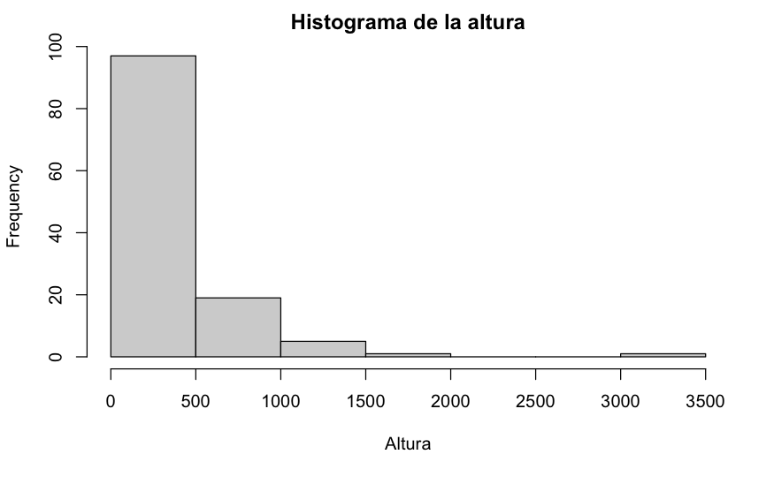

```r
hist(estaciones$ALTURA, main = "Histograma de la altura", xlab = "Altura")
```

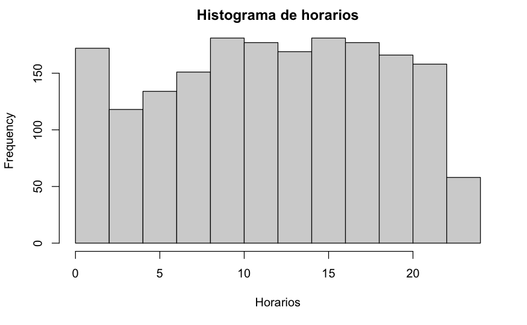

```r
hist(horarios$HORA, main = "Histograma de horarios", xlab = "Horarios")
```

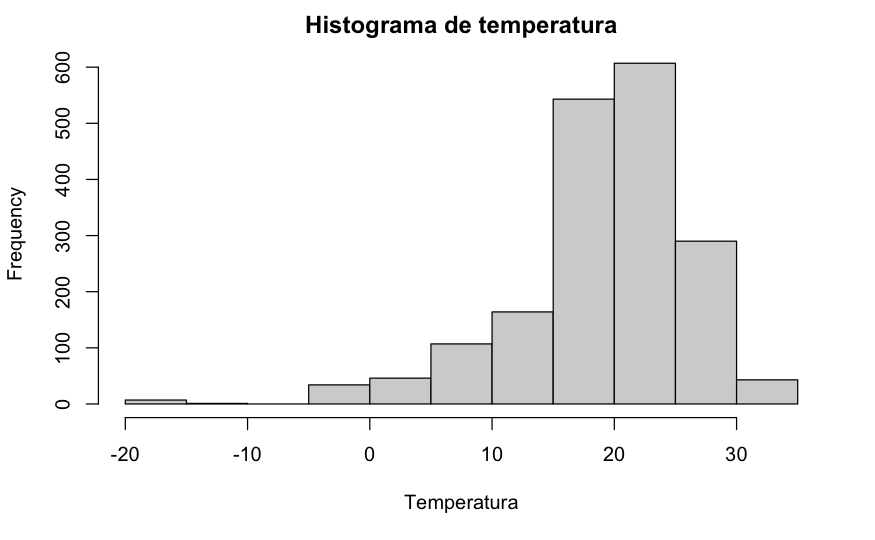

```r
hist(horarios$TEMP, main = "Histograma de temperatura", xlab = "Temperatura")
```

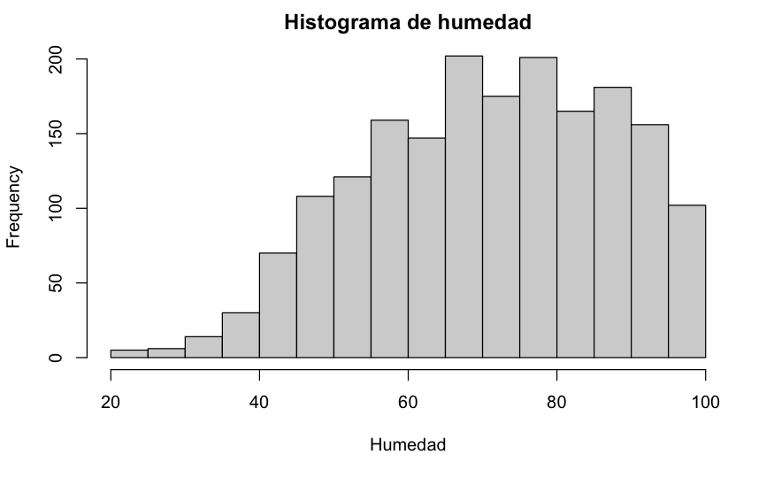

```r
hist(horarios$HUM, main = "Histograma de humedad", xlab = "Humedad")
```

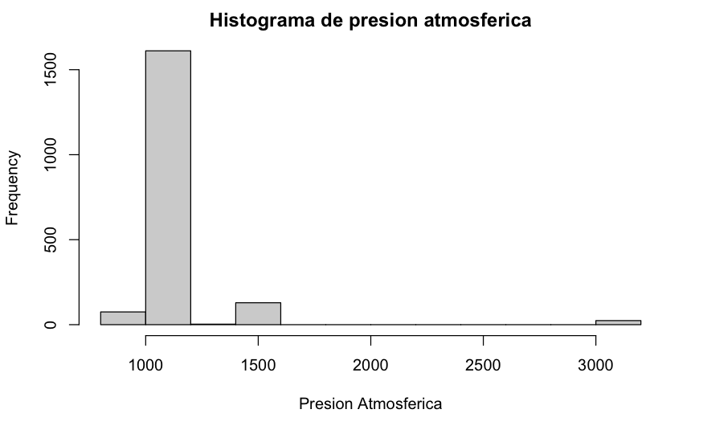

```r
hist(horarios$PNM, main = "Histograma de presion atmosferica", xlab = "Presion Atmosferica")
```

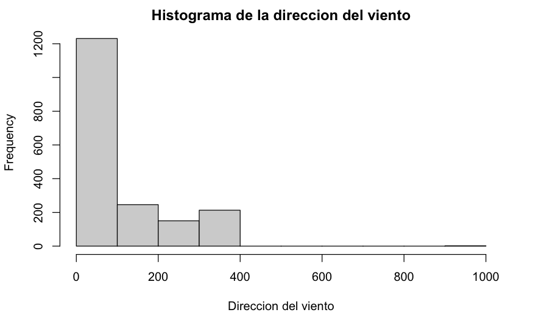

```r
hist(horarios$DD, main = "Histograma de la direccion del viento", xlab = "Direccion del viento")
```

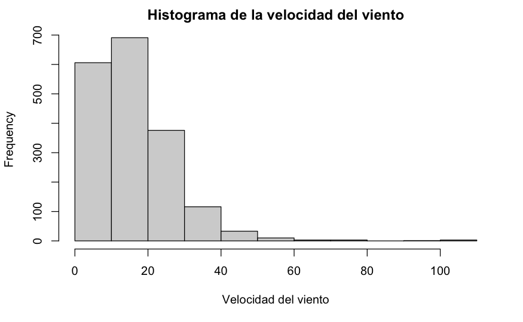

```r
hist(horarios$FF, main = "Histograma de la velocidad del viento", xlab = "Velocidad del viento")
```

Creamos unos boxplot para visualizar la distribucionde datos que potencialmente nos interecen para proceder con el analisis

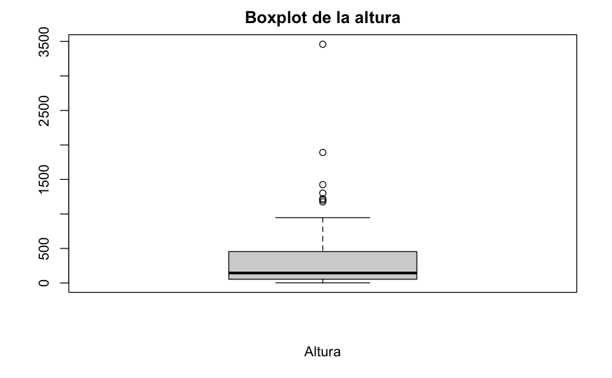

```r
boxplot(estaciones$ALTURA, main = "Boxplot de la altura", xlab = "Altura")
```

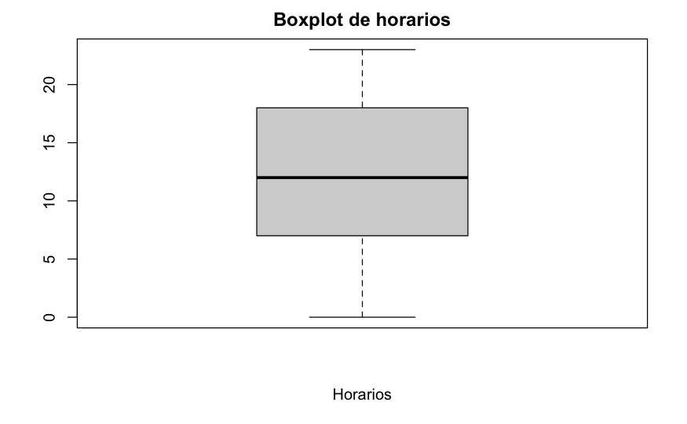

```r
boxplot(horarios$HORA, main = "Boxplot de horarios", xlab = "Horarios")
```

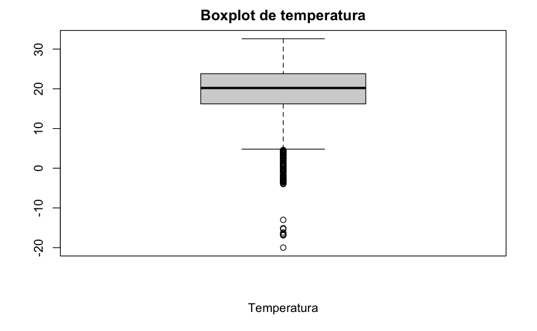

```r
boxplot(horarios$TEMP, main = "Boxplot de temperatura", xlab = "Temperatura")
```

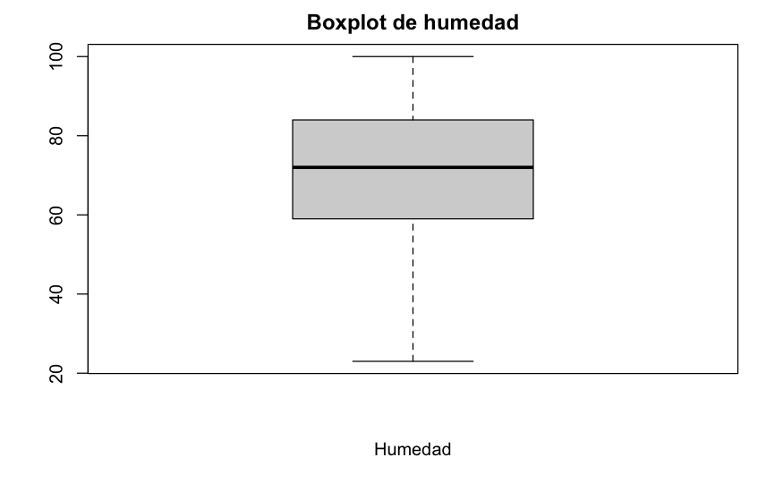

```r
boxplot(horarios$HUM, main = "Boxplot de humedad", xlab = "Humedad")
```

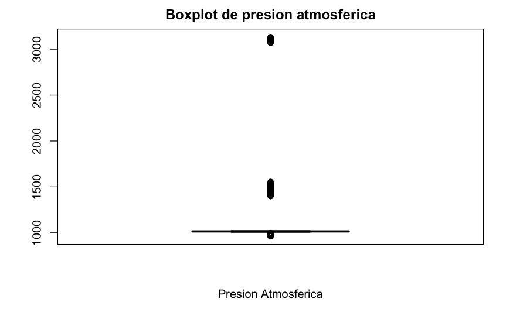

```r
boxplot(horarios$PNM, main = "Boxplot de presion atmosferica", xlab = "Presion Atmosferica")
```

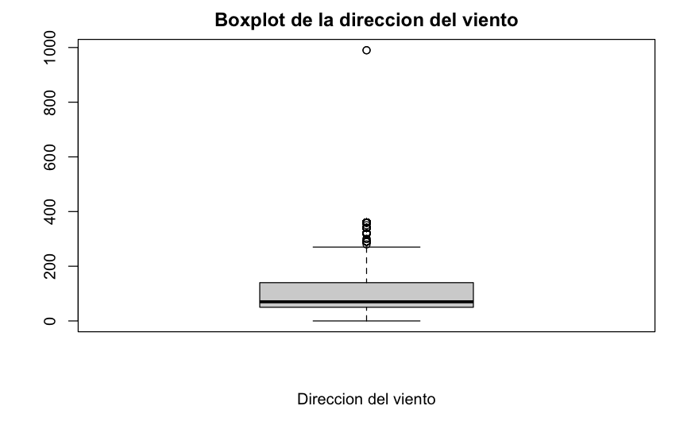

```r
boxplot(horarios$DD, main = "Boxplot de la direccion del viento", xlab = "Direccion del viento")
```

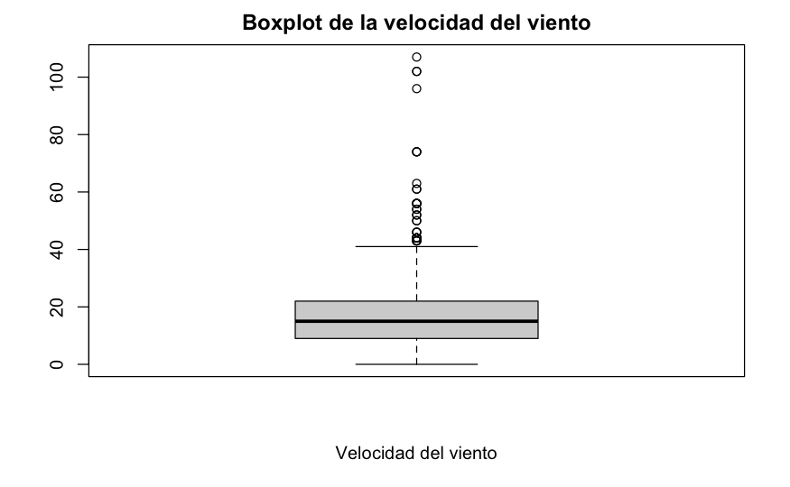

```r
boxplot(horarios$FF, main = "Boxplot de la velocidad del viento", xlab = "Velocidad del viento")
```

Ahora, veamos que tan correlacionadas estan estas variables

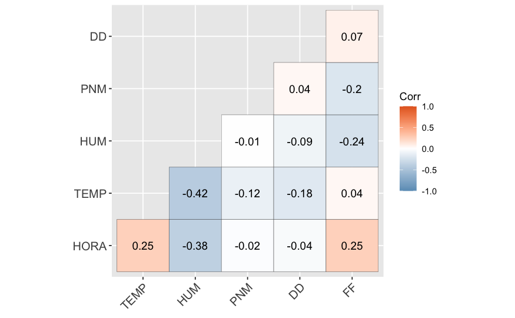

```r
corr <- cor(horarios[, c(2,3,4,5,6,7)], use = "complete.obs")

ggcorrplot(corr, type = "lower", outline.col = "black",
 lab=TRUE,
 ggtheme = ggplot2::theme_gray,
 colors = c("#6D9EC1", "white", "#E46726"))
```

Las variables que mas correlacionan con la velocidad del viento son HUMEDAD (negativamente) y HORA (positivamente). Tambien vemos que HORA y TEMPERATURA correlacionan negativamentecon HUMEDAD. Por ultimo, HORA y TEMPERATURA correlacionan positivamente

Analizamos la simetria de la variable que representa la velocidad del viento ya que es la que mas nos interesa.

```r
skew(horarios$FF)
```

```
[1] 1.646538
```

```r
kurtosi(horarios$FF)
```

```
[1] 7.597582
```

La medida de asimetria y kurtosi terminan de validar lo que observamos en el histograma. La variable FF es asimetrica a derecha y tiene una mayor concentracion de valores muy cerca de la media de la distribución y muy lejos de la cola de la distribucion.

# Armado de dataset

Un detalle no menor del dataset de estaciones es que las latitudes y longitudes estan expresadads en grados y minutos. Para poder trabajar con ellas, necesitamos que esten expresadas en valores decimales. Por eso, en el siguiente bloque de codigo vamos a usar la funcion dms2dd para hacer esta conversion.

```r
# creamos dos vectores vacios
latitud <- c()
longitud <- c()

# iteramos por cada fila del dataset de estaciones y hacemos la convesion de latitud y longitud
for(i in 1:nrow(estaciones)) {
     latitud[i] <- dms2dd(dd = estaciones[i, "LATITUD_GRADOS"], mm = estaciones[i, "LATITUD_MINUTOS"], ss = 0, ns = "S")
     longitud[i] <- dms2dd(dd = estaciones[i, "LONGITUD_GRADOS"], mm = estaciones[i, "LONGITUD_MINUTOS"], ss = 0, ns = "S")
}

# asignamos a latitud y longitud los valores convertidos
estaciones['LATITUD'] <- latitud
estaciones['LONGITUD'] <- longitud
```

Necesitamos unir las dos tablas usando la variable NOMBRE como punto para combinar los datasets

```r
data <- full_join(estaciones, horarios, by = c("NOMBRE" = "NOMBRE"))

glimpse(data)
```

```
Rows: 1,867
Columns: 18
$ NOMBRE           <chr> "BASE BELGRANO II", "BASE BELGRANO II", "BASE BELGRANO II", "BASE BELGRANO II", "BASE …
$ PROVINCIA        <chr> "ANTARTIDA", "ANTARTIDA", "ANTARTIDA", "ANTARTIDA", "ANTARTIDA", "ANTARTIDA", "ANTARTI…
$ LATITUD_GRADOS   <int> 77, 77, 77, 77, 77, 77, 77, 77, 62, 62, 62, 62, 62, 62, 62, 62, 63, 63, 63, 63, 63, 63…
$ LATITUD_MINUTOS  <int> 52, 52, 52, 52, 52, 52, 52, 52, 14, 14, 14, 14, 14, 14, 14, 14, 24, 24, 24, 24, 24, 24…
$ LONGITUD_GRADOS  <int> 34, 34, 34, 34, 34, 34, 34, 34, 58, 58, 58, 58, 58, 58, 58, 58, 56, 56, 56, 56, 56, 56…
$ LONGITUD_MINUTOS <int> 34, 34, 34, 34, 34, 34, 34, 34, 38, 38, 38, 38, 38, 38, 38, 38, 59, 59, 59, 59, 59, 59…
$ ALTURA           <int> 256, 256, 256, 256, 256, 256, 256, 256, 11, 11, 11, 11, 11, 11, 11, 11, 24, 24, 24, 24…
$ NRO              <int> 89034, 89034, 89034, 89034, 89034, 89034, 89034, 89034, 89053, 89053, 89053, 89053, 89…
$ NroOACI          <chr> "SAYB", "SAYB", "SAYB", "SAYB", "SAYB", "SAYB", "SAYB", "SAYB", "SAYJ", "SAYJ", "SAYJ"…
$ LATITUD          <dbl> -77.86667, -77.86667, -77.86667, -77.86667, -77.86667, -77.86667, -77.86667, -77.86667…
$ LONGITUD         <dbl> -34.56667, -34.56667, -34.56667, -34.56667, -34.56667, -34.56667, -34.56667, -34.56667…
$ FECHA            <int> 20042021, 20042021, 20042021, 20042021, 20042021, 20042021, 20042021, 20042021, 200420…
$ HORA             <int> 0, 3, 6, 9, 12, 15, 18, 21, 0, 3, 6, 9, 12, 15, 18, 21, 0, 3, 6, 9, 12, 15, 18, 21, 0,…
$ TEMP             <dbl> -20.0, -16.2, -16.9, -13.0, -15.1, -16.6, -15.3, -16.8, -0.1, -0.5, -0.9, -0.5, 0.3, 1…
$ HUM              <int> 70, 72, 80, 73, 86, 66, 77, 85, 88, 82, 77, 75, 84, 92, 99, 91, 43, 49, 67, 81, 67, 62…
$ PNM              <dbl> 975.7, 970.4, 966.7, 964.2, 961.4, 963.0, 964.8, 967.1, 992.9, 993.0, 992.9, 994.6, 99…
$ DD               <int> 140, 140, 110, 140, 160, 160, 90, 110, 230, 230, 270, 290, 290, 320, 320, 320, 160, 20…
$ FF               <dbl> 13, 30, 50, 52, 74, 61, 44, 13, 15, 15, 26, 28, 41, 37, 50, 74, 20, 7, 13, 7, 11, 46, …
```

Eliminamos las observaciones nulas en el dataset

```r
data = na.omit(data)
```

Volvemos realizar el grafico de correlacion incluyendo la variable altura.

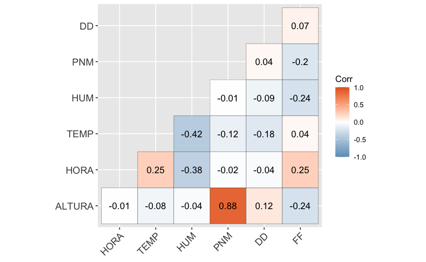

```r
corr <- cor(data[, c(7,13,14,15,16,17,18)], use = "complete.obs")

ggcorrplot(corr, type = "lower", outline.col = "black",
 lab=TRUE,
 ggtheme = ggplot2::theme_gray,
 colors = c("#6D9EC1", "white", "#E46726"))
```